# **Mini-Projet Statistique**

*ZHAO Fubang(Group 4)*

*19:45:28 25 oct 2016*

Je vous prie par avance de me pardonner si je commets des erreurs en français.

# Exercice 1

```r
set.seed(42,kind = "Marsaglia-Multicarry")
```

### 1.1

Le $g(\theta)$ pour $0<\theta<1$ est
$$\begin{split}
g(\theta)&=\sum_{k=1}^{+\infty}k\theta(1-\theta)^{k-1} \\
&= \theta\sum_{k=1}^{+\infty}-\frac{\partial{(1-\theta)}^k}{\partial x_1}\\
&=-\theta\frac{1}{\partial \theta}(\frac{1}{1-(1-\theta)})\\
&=\frac{1}{\theta}
\end{split}$$

### 1.2

Par le mesure de comptage sur $\mathbb{N}^*=\{1,2,3,...,\}$ le modèle est dominé. Parce que $\mathbb{N}^*=\{1,2,3,...,\}$ est dénombrable.

### 1.3

Car le modèle $\{P\theta,\theta\in]0,1[\}$ est régulier, on a
$$var_{\theta}[T(x)]\ge \frac{g'(\theta)^2}{I(\theta)}$$
Et la variance de $T(x)$ est
$$\begin{split}
var_{\theta}[T(x)]&=var_{\theta}(\frac{1}{n}\sum_{i=1}^{n}{X_{i}})\\
&=\frac{1}{n}var_{\theta}(x_1)\\
&=\frac{1-\theta}{n\theta^2}
\end{split}$$

Car $(X_1,...,X_n)$ sont *n v.a. i.i.d.* au sens des hypothèses du théorème de Cramér-Rao, la quantité d’information de Fisher est

$$\begin{split}
I(\theta)&=nI_1(\theta)=n\mathbb{E}_\theta[(\frac{\partial{log\theta(1-\theta)^{k-1}}}{{\partial \theta}})^2]\\
&=n\mathbb{E}_\theta[(\frac{1}{\theta}-\frac{k-1}{1-\theta})^2]\\
&=n var(\frac{k-1}{1-\theta})\\
&=\frac{nvar(x)}{(1-\theta)^2}\\
&=\frac{n}{(1-\theta)\theta^2}
\end{split}$$
Et le paramètre d’intérêt $g(\theta)$ est
$$g(\theta)=\mathbb{E}_\theta(T(x))=\mathbb{E}_\theta(X_1)=\frac{1}{\theta}$$
On peut conclure: l’estimateur $T(X)$ de $g(\theta)$ est non biaisé et vérifie
$$var_\theta[T(x)]=\frac{g'(\theta)^2}{I(\theta)}$$

DoncT(X) atteint la borne de Cramér-Rao, C’est à dire, $T(x)$est un estimateur UVMB.

### 1.4

Le risque quadratique de $S_h$ est
$$\begin{split}
R(\theta,S_h)&=\mathbb{E}_\theta[(g(\theta)-S_h(X))^2]\\
&=\mathbb{E}_\theta[(\frac{1}{\theta}-hT(X))^2]\\
&=\frac{1}{\theta^2}-\frac{2h}{\theta^2}+h^2(\frac{1}{\theta^2}+var(T(X)))\\
&<R(\theta,T)=var(T(X))
\end{split}$$
C’est à dire:

$$\theta^2(h^2-1)var(T(X)+(h-1)^2<0$$
Si $h>1$, on a
$$h\,n'existe\,pas$$
Si $h<1$, on a
$$\frac{n-1+\theta}{n+1-\theta}<h<1$$
Alors quand on a $\frac{n-1+\theta}{n+1-\theta}<h<1$, on va avoir $R(\theta,S_h)<R(\theta,T)$. Parce que$R=\frac{1}{\theta^2}-\frac{2h}{\theta^2}+h^2(\frac{1}{\theta^2}+var(T(X)))$ est une fonction quadratique. Donc evidemment,
$$h^*(\theta)=\frac{1}{\theta^2var(T(X))+1}=\frac{n}{n+1-\theta}$$

### 1.5

Car $h^*(\theta)=\frac{1}{\theta^2var(T(X))+1}=\frac{n}{n+1-\theta}$, c’est à dire $h^*$ est une fonction de $\theta$, donc il n’exsite pas $h^*$ qui minimse le risque quadratique uniformément en $\theta$.

### 1.6

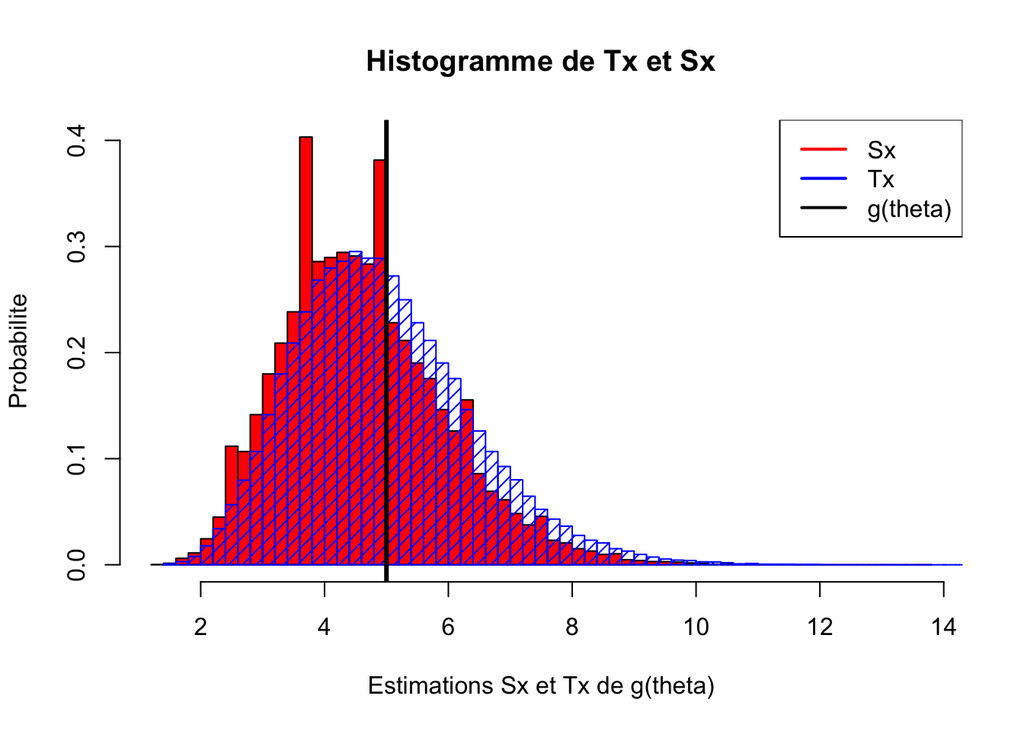

```r
#Exercice1
#a
h = 10/(11-0.2)
theta_0 = 0.2
n = 10
M = 10**5
Z = matrix(nrow = n, ncol = M)
for(i in 1:M)
{
  v= rgeom(10, theta_0)
  Z[,i] = matrix(v, nrow=10)+1
}
#b
Tx = colMeans(Z)
Sx = h*Tx
#c
hist(Sx, col = "red", probability = TRUE,
     main = "Histogramme de Tx et Sx", breaks = 50,
     xlab = "Estimations Sx et Tx de g(theta)",
     ylab = "Probabilite")
hist(Tx, col = "blue", probability = TRUE, add = TRUE,
     density = 15, breaks = 50)
abline(v = 1/theta_0, lwd = 3)
legend("topright", lwd = 2,col = c("red", "blue", "black"),
       legend = c("Sx", "Tx","g(theta)"))
```

```r
mean(Sx)
```

```
## [1] 4.627897
```

```r
mean(Tx)
```

```
## [1] 4.998129
```

```r
#d
L1 = (Tx-mean(Tx))**2
Lh = (Sx-mean(Tx))**2
```

```r
#e
#R(theta_0,T)
(1-theta_0)/(n*(theta_0**2))
```

```
## [1] 2
```

```r
#R(theta_0,S)
(1/theta_0**2+(1-theta_0)/(n*(theta_0**2)))*h**2-(2/theta_0**2)*h+1/theta_0**2
```

```
## [1] 1.851852
```

```r
mean(L1)#l'approximation de R(theta_0,T)
```

```
## [1] 1.992093
```

```r
mean(Lh)#l'approximation de R(theta_0,S)
```

```
## [1] 1.84497
```

Avec $h=\frac{10}{11-0.2}$, qui est inclus dans $\frac{n-1+\theta}{n+1-\theta}<h<1$, on a toujours $R_S<R_T$. Cela, même pour les estimations, est conformé à la conclusion de la quesiton 4.

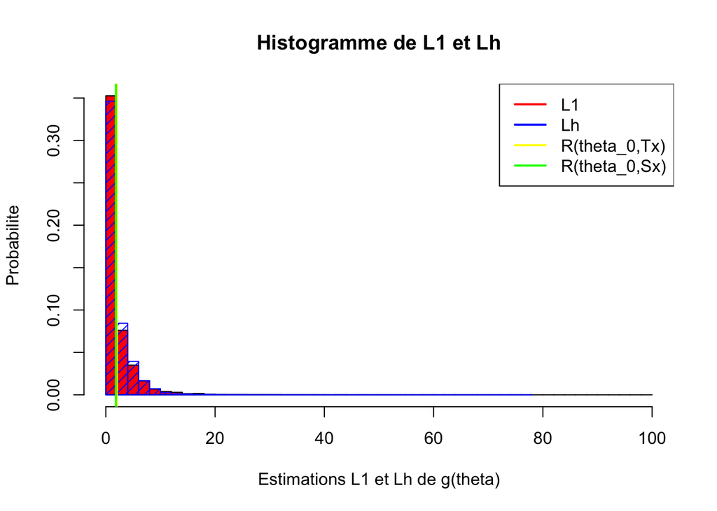

```r
#f
hist(L1, col = "red",
     probability = TRUE,
     main = "Histogramme de L1 et Lh",
     breaks = 50,
     xlab = "Estimations L1 et Lh de g(theta)",
     ylab = "Probabilite")
hist(Lh, col = "blue", probability = TRUE, add = TRUE,
     density = 15, breaks = 50)
abline(v = mean(L1), lwd = 2, col = "yellow")
abline(v = mean(Lh),lwd = 2, col ="green")
legend("topright", lwd = 2,col = c("red", "blue", "yellow", "green"),
       legend = c("L1", "Lh", "R(theta_0,Tx)", "R(theta_0,Sx)"))
```

# Exercice 2

### 2.1

Car le résultat est à nouveau une loi Beta, dont on dois préciser les paramètres
$$\begin{split}
\pi(\theta|x) &= \frac{p_\theta(x)\pi(\theta)}{m(x)}\\
&\propto p_\theta(x)\pi(\theta)\\
&=\prod_{i=1}^{n} p_\theta(x_i)\pi(\theta)\\
&=\frac{\Gamma(\alpha+\beta)}{\Gamma(\alpha)\Gamma(\beta)}\theta^{\alpha-1}(1-\theta)^{\beta-1}\theta^n(1-\theta)^{\Sigma_{i=1}^{n}x_i-n}\\
&=\frac{\Gamma(\alpha+\beta)}{\Gamma(\alpha)\Gamma(\beta)}\theta^{\alpha+n-1}(1-\theta)^{\beta+\Sigma_{i=1}^{n}x_i-n-1}
\end{split}$$
Donc $\pi(\theta|x)$ est une loi Beta: $Beta(\alpha+n,\, \beta+\Sigma_{i=1}^{n}x_i-n)$.

### 2.2

$$\mathbb{E}_\pi(\theta|x)=\frac{\alpha+n}{\alpha+\beta+\Sigma_{i=1}^{n}x_i}$$
Car $\mathbb{E}_\pi(\theta|x)$ est une fonction de $X$, on peut considérer $M(X)=E_\pi(\theta|X)$ comme un estimateur de $\theta_0$.

### 2.3

$$\mathbb{E}_\pi(\theta|x)=\frac{\frac{\alpha}{n}+1}{\frac{\alpha+\beta}{n}+\frac{1}{n}\Sigma_{i=1}^{n}x_i}$$
Car la loi des grands nombres, lorsque $n\to+\infty$, $\mathbb{E}_\pi(\theta|x)\to\frac{1}{\overline{X}}=\frac{1}{\frac{1}{\theta}}=\theta$.

Donc $M_n=\mathbb{E}_\pi(\theta|X^n)$ converge $\mathbb{P}_{\theta_0}-presque$ sûrement vers $\theta_0$.

### 2.4

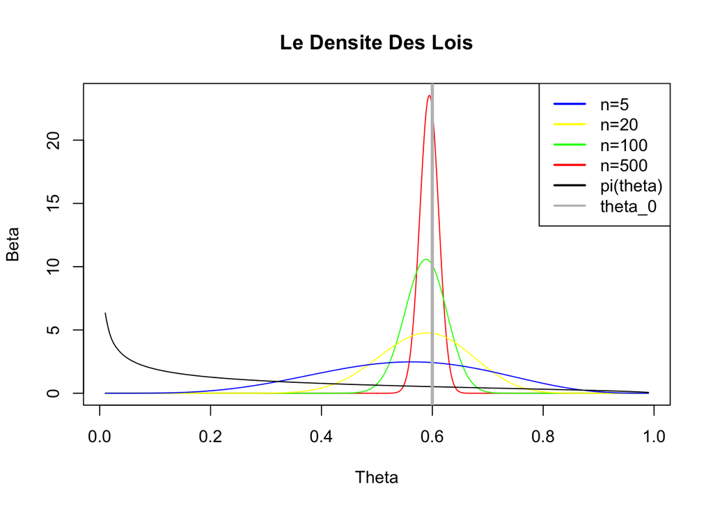

```r
#Excercice2
#a
grille = seq(0, 1, by = 0.01)
L = length(grille)
grille = grille[-c(1,L)]
x= rgeom(500, 0.6)+1
#b
n_pi = 500
v_beta = dbeta(grille, 1/2+n_pi, 3/2-n_pi+sum(x[1:n_pi]))
sp = spline(grille, v_beta, n=1000)
plot(sp,type="l", col="red", xlab = "Theta", ylab = "Beta",
     main = "Le Densite Des Lois")
n_pi = 100
v_beta = dbeta(grille, 1/2+n_pi, 3/2-n_pi+sum(x[1:n_pi]))
sp = spline(grille, v_beta, n=1000)
lines(sp, type="l", col="green")
n_pi = 20
v_beta = dbeta(grille, 1/2+n_pi, 3/2-n_pi+sum(x[1:n_pi]))
sp = spline(grille, v_beta, n=1000)
lines(sp, type="l", col="yellow")
n_pi = 5
v_beta = dbeta(grille, 1/2+n_pi, 3/2-n_pi+sum(x[1:n_pi]))
sp = spline(grille, v_beta, n=1000)
lines(sp, type="l", col="blue")

v_pi = dbeta(grille, 1/2, 3/2)
sp = spline(grille, v_pi, n=1000)
lines(sp, type="l", col="black")

abline(v=0.6, col="grey", lwd = 3)
legend("topright", lwd = 2,col = c("blue", "yellow", "green", "red", "black", "grey"),
       legend = c("n=5", "n=20", "n=100", "n=500", "pi(theta)","theta_0"))
```

On peut voir que, lorque que n est plus grand, l’ésperance s’approche plus du vrai paramètre $\theta_0$ et la courbe est plus proche de la line de $\theta_0$ .

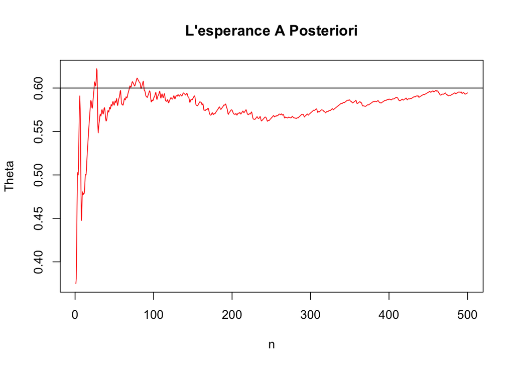

```r
#c
E_theta_x = (1/2+(1:500))/(2+cumsum(x[1:500]))
sp = spline(1:500, E_theta_x, n=1000)
plot(sp,type="l", col="red", xlab = "n", ylab = "Theta",
     main = "L'esperance A Posteriori")
abline(h=0.6)
```

On peut voir que, lorsque n augmente, l’ésperance a posterior converge vers le vrai $\theta_0=0.6$.

# Exercice 3

### 3.1

L“espace des paramètres$\Theta$ du modèle est $\Theta=\{\mu\ge0\}$, $\Theta_0=\{\mu=0\}$, $\Theta_1=\{\mu>0\}$.

### 3.2

On a
$$S_n(X)\sim\mathcal{N}(\mu,\delta^2)$$
On a $\mathbb{E}_{H_0}[S_n(X)]=0$, $var_{H_0}(S_n(X))=\frac{1}{n}$, donc la loi de $S_n(X)$ est
$$S_n(X)\sim\mathcal{N}(0,\frac{1}{n})$$

On a
$$\sqrt{n}S_n(X)\sim\mathcal{N}(\mu,\delta^2)$$
On a $\mathbb{E}_{H_0}[\sqrt{n}S_n(X)]=0$, $var_{H_0}(\sqrt{n}S_n(X))=1$, donc la loi de $\sqrt{n}S_n(X)$ est
$$\sqrt{n}S_n(x)\sim\mathcal{N}(0,1)$$

Pour que la probabilité de rejeter à tort $H_0$ soit inférieure ou égale à $\alpha=5/100$, on a

$$\int_{-\infty}^{\sqrt{n}A} p(\sqrt{n}S_n(x))\, \mathrm{d}(\sqrt{n}S_n(x))\ge 1-\frac{0.05}{2}=0.975$$
Donc
$$A=\frac{F^{\gets}(0.975)}{\sqrt{n}}$$

### 3.3

```r
#Exercice3
#3
a = 0.05
p_a = 1-(a/2)
A_10 = qnorm(p_a,sd = 1/10**0.5)
A_100 = qnorm(p_a,sd = 1/100**0.5)
A_1000 = qnorm(p_a, sd = 1/1000**0.5)
A_10;A_100;A_1000
```

```
## [1] 0.619795
```

```
## [1] 0.1959964
```

```
## [1] 0.0619795
```

### 3.4

L’espérance de $X$ est
$$\mathbb{E}(x)=\mathbb{E}(e^{logx})=\int_{0}^{+\infty}e^{logx}\frac{1}{\sqrt{2\pi\sigma^2}}exp(-\frac{(logx-\mu)^2}{2\sigma^2})\mathrm{d}(logx)$$
On utilise $y$ à replacer $logx$, donc
$$\begin{split}
\mathbb{E}(x)&=\int_{0}^{+\infty}e^{logx}\frac{1}{\sqrt{2\pi\sigma^2}}exp(-\frac{(logx-\mu)^2}{2\sigma^2})\mathrm{d}(logx)\\
&=\int_{-\infty}^{+\infty}e^{y}\frac{1}{\sqrt{2\pi\sigma^2}}exp(-\frac{(y-\mu)^2}{2\sigma^2})\mathrm{d}y\\
&=\int_{-\infty}^{+\infty}\frac{1}{\sqrt{2\pi\sigma^2}}exp(-\frac{(y-(\sigma^2+2\mu))^2}{2\sigma^2}+\frac{\sigma^2}{2}+\mu)\mathrm{d}y\\
&=e^{\mu+\frac{\sigma^2}{2}}
\end{split}$$
Car $\sigma^2=1$, on a:
$$\mathbb{E}(x)=e^{\mu+\frac{1}{2}}$$

```r
#4
exp(0.1+0.5)
```

```
## [1] 1.822119
```

### 3.5

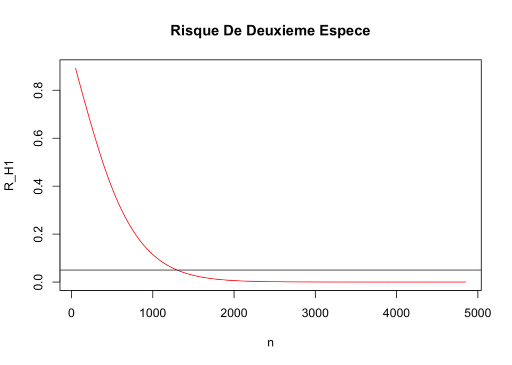

```r
#5
grille_risque = seq(50,5000,200)
R_H1 = c()
for (n_3 in grille_risque)
{
  s = pnorm(qnorm(p_a,sd = 1/n_3**0.5), mean = 0.1, sd=1/n_3**0.5)
  b = pnorm(-qnorm(p_a,sd = 1/n_3**0.5), mean = 0.1, sd=1/n_3**0.5)
  v= s-b
  R_H1 = append(R_H1, v)
}
sp = spline(grille_risque, R_H1, n=1000)
plot(sp,type="l", col="red", xlab = "n", ylab = "R_H1",
     main = "Risque De Deuxieme Espece")
abline(h=0.05)
```

```r
n_0 = 0
for (n_3 in grille_risque) {
  s = pnorm(qnorm(p_a,sd = 1/n_3**0.5), mean = 0.1, sd=1/n_3**0.5)
  b = pnorm(-qnorm(p_a,sd = 1/n_3**0.5), mean = 0.1, sd=1/n_3**0.5)
  v= s-b
  if(v<=0.05)
  {
    n_0 = n_3
    break
  }
}
n_0
```

```
## [1] 1450
```

Donc pour n variant de 50 à 5000, sur une grille de pas $h=200$, on a la première approximation de la plus petite valeur de $n_0=1450$.

### 3.6

```r
#6
for (n_3 in 1:5000) {
  s = pnorm(qnorm(p_a,sd = 1/n_3**0.5), mean = 0.1, sd=1/n_3**0.5)
  b = pnorm(-qnorm(p_a,sd = 1/n_3**0.5), mean = 0.1, sd=1/n_3**0.5)
  v= s-b
  if(v<=0.05)
  {
    n_0 = n_3
    break
  }
}
n_0
```

```
## [1] 1300
```

Donc la valeur exacte de $n_0$ est 1300.